# GenoplotR: A versatil package to visualize gene context and synteny comparisons

Arturo Vera-Ponce de Leon

[link](http://genoplotr.r-forge.r-project.org/)

# *The amount of gene and genome data obtained by next-generation sequencing technologies generates a need for comparative visualization tools.*

## GenoPlotR Basic Code:

### To perform a basic plot using GenoPlotR you need to import the library genoPlotR like:

```r
library(genoPlotR)
```

> Othe useful libraries:
1. **dplyr**
- Modify,parse and edit tables and dataframes
2. **xlsx**
- Manipulate excel worksheets

```r
library(dplyr)
library(xlsx)
```

# Inputs to GenoPlot:

## genoPlotR uses as main object:

** *dna_seg* : which represent segments of DNA containing genes, their length and the strain (+ or -) **

To generate these object you need to ‘feed’ *dna_seg* with a data frame containing these elements. The easy way to do it is by reading a General Feature Format (GFF) Table:

> Now let´s read a small gff from xlsx file

```r
singleGff <- read.xlsx("gff_single.xlsx",sheetIndex = 1, header = F)
singleGff
```

```
##            X1    X2           X3            X4    X5    X6 X7    X8
## 1 PAB51_PUL17 PUL17 PAB_51_02163 contig-100_18 36287 38098  - 16238
## 2 PAB51_PUL17 PUL17 PAB_51_02164 contig-100_18 38385 41486  +   287
## 3 PAB51_PUL17 PUL17 PAB_51_02165 contig-100_18 41567 43252  +    81
## 4 PAB51_PUL17 PUL17 PAB_51_02166 contig-100_18 43457 44869  +   205
## 5 PAB51_PUL17 PUL17 PAB_51_02167 contig-100_18 44920 46458  +    51
##             X9  X10
## 1 PAB_51_02163 GH32
## 2 PAB_51_02164 susC
## 3 PAB_51_02165 susD
## 4 PAB_51_02166  unk
## 5 PAB_51_02167 GH32
```

```r
class(singleGff)
```

```
## [1] "data.frame"
```

As you see these gff file has all the elements necessary for plotting let’s do a simple plot:

**First you need to name the colums in the new data frame:**

```r
names <- c("genome",    "pulid",    "protein_id",   "contig", "start",  "end",  "strand",   "dist", "protein_name","annot")
colnames(singleGff) <- names
singleGff
```

```
##        genome pulid   protein_id        contig start   end strand  dist
## 1 PAB51_PUL17 PUL17 PAB_51_02163 contig-100_18 36287 38098      - 16238
## 2 PAB51_PUL17 PUL17 PAB_51_02164 contig-100_18 38385 41486      +   287
## 3 PAB51_PUL17 PUL17 PAB_51_02165 contig-100_18 41567 43252      +    81
## 4 PAB51_PUL17 PUL17 PAB_51_02166 contig-100_18 43457 44869      +   205
## 5 PAB51_PUL17 PUL17 PAB_51_02167 contig-100_18 44920 46458      +    51
##   protein_name annot
## 1 PAB_51_02163  GH32
## 2 PAB_51_02164  susC
## 3 PAB_51_02165  susD
## 4 PAB_51_02166   unk
## 5 PAB_51_02167  GH32
```

**Now genoPlot ask for a dataframe with the name, start, end and strand**

```r
singleDF <- data.frame(name=singleGff$annot,
                   start= singleGff$start,
                   end=singleGff$end,
                   strand=singleGff$strand)
singleDF
```

```
##   name start   end strand
## 1 GH32 36287 38098      -
## 2 susC 38385 41486      +
## 3 susD 41567 43252      +
## 4  unk 43457 44869      +
## 5 GH32 44920 46458      +
```

**Next, we can use this dataframe to create a *dna_seg* object**

```r
dna_seg <- dna_seg(singleDF)
class(dna_seg)
```

```
## [1] "dna_seg"    "data.frame"
```

```r
dna_seg
```

```
##   name start   end strand  col fill lty lwd pch cex gene_type
## 1 GH32 36287 38098     -1 blue blue   1   1   8   1    arrows
## 2 susC 38385 41486      1 blue blue   1   1   8   1    arrows
## 3 susD 41567 43252      1 blue blue   1   1   8   1    arrows
## 4  unk 43457 44869      1 blue blue   1   1   8   1    arrows
## 5 GH32 44920 46458      1 blue blue   1   1   8   1    arrows
```

**Additionally, genoPlot is able to add annotations to the genes for this we need to parse the annotation colum and to indicate into the dataframe the possition and direction of these annotations**

```r
annot <- annotation(x1=middle(dna_seg),
                    text=dna_seg$name, rot=18)
class(annot)
```

```
## [1] "annotation" "data.frame"
```

```r
annot
```

```
##        x1 x2 text color rot
## 1 37192.5 NA GH32 black  18
## 2 39935.5 NA susC black  18
## 3 42409.5 NA susD black  18
## 4 44163.0 NA  unk black  18
## 5 45689.0 NA GH32 black  18
```

> **With these trhee data frames now we can create a plot with the possition and annotation using the *plot_gene_map* function like:**

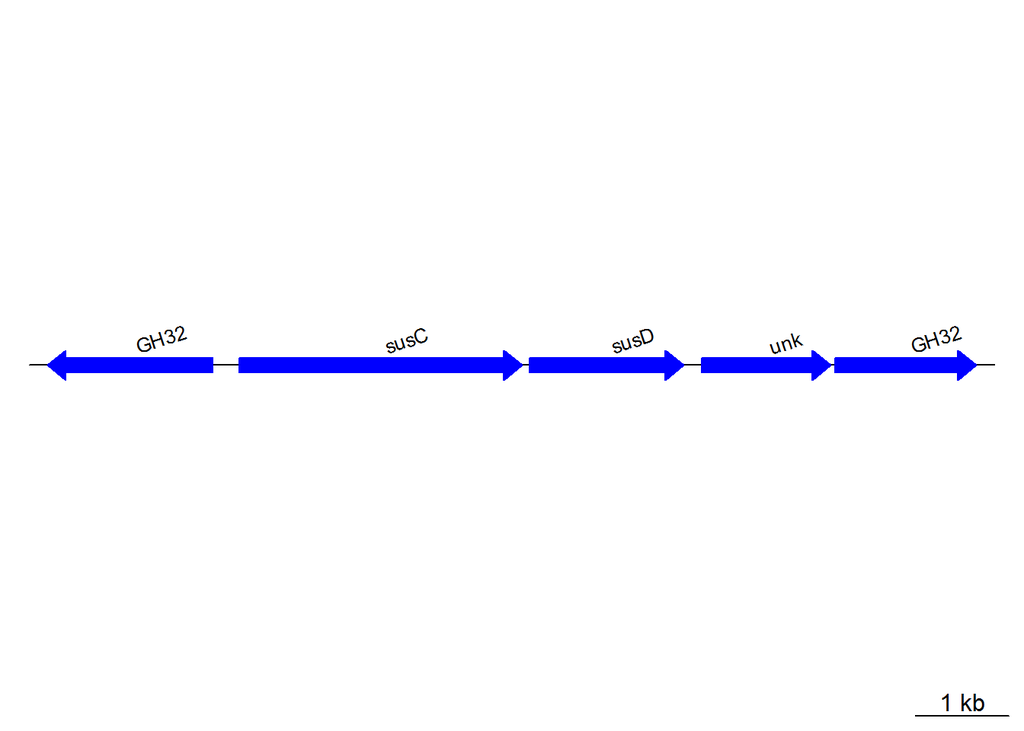

```r
dnasegs <- list(dna_seg)
plot_gene_map(dna_segs=dnasegs,annotations = annot)
```

**Remember genoPlotR uses a list of *dna_seg* objects for plotting**

> As you can see now we have created a plot with arrows and names, but it is difficult to differentiate among all different genes and annotations

**So lets add a color code for each different gene**

For this, we need to add a new column to the singleDF using the color code we like, so let’s use an *ifelse* loop and look for the annotation by *grepl* function. We want:

1. All GH genes in green
2. All susC genes in purple
3. All susD genes in orange
4. Any other gene in gray

```r
singleGff$color <- ifelse(grepl("GH", singleGff$annot),"yellowgreen",
                          ifelse(grepl("susC",singleGff$annot), "purple",
                                 ifelse(grepl("susD",singleGff$annot),"orange",
                                        "gray")))
singleGff
```

```
##        genome pulid   protein_id        contig start   end strand  dist
## 1 PAB51_PUL17 PUL17 PAB_51_02163 contig-100_18 36287 38098      - 16238
## 2 PAB51_PUL17 PUL17 PAB_51_02164 contig-100_18 38385 41486      +   287
## 3 PAB51_PUL17 PUL17 PAB_51_02165 contig-100_18 41567 43252      +    81
## 4 PAB51_PUL17 PUL17 PAB_51_02166 contig-100_18 43457 44869      +   205
## 5 PAB51_PUL17 PUL17 PAB_51_02167 contig-100_18 44920 46458      +    51
##   protein_name annot       color
## 1 PAB_51_02163  GH32 yellowgreen
## 2 PAB_51_02164  susC      purple
## 3 PAB_51_02165  susD      orange
## 4 PAB_51_02166   unk        gray
## 5 PAB_51_02167  GH32 yellowgreen
```

**Now Using this new datafame we just need to modify the first *singleDF* data frame adding the color colum like this:**

```r
singleDFColor <- data.frame(name=singleGff$annot,
                   start= singleGff$start,
                   end=singleGff$end,
                   strand=singleGff$strand,
                   col=singleGff$color)
singleDFColor
```

```
##   name start   end strand         col
## 1 GH32 36287 38098      - yellowgreen
## 2 susC 38385 41486      +      purple
## 3 susD 41567 43252      +      orange
## 4  unk 43457 44869      +        gray
## 5 GH32 44920 46458      + yellowgreen
```

**We can modify a little bit the previous code to produce new plots**

- Filling the arrows can be done by adding the *fill* flag to the *dna_seg* and specify to use the new column color

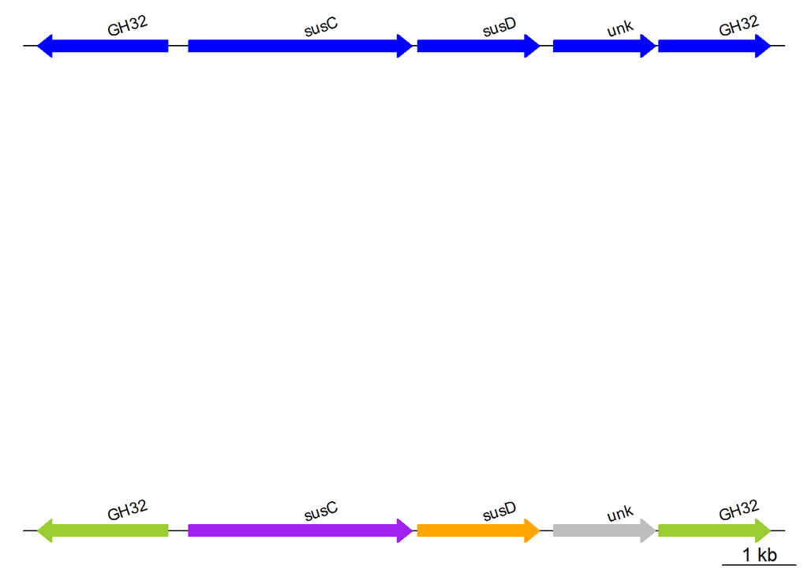

```r
dna_segC <- dna_seg(singleDFColor,fill=singleDFColor$col)
annotC <- annotation(x1=middle(dna_segC),
                    text=dna_segC$name, rot=18)
annotations <- list(annot,annotC)
dnasegs <- list(dna_seg,dna_segC)
plot_gene_map(dna_segs=dnasegs,annotations = annotations)
```

> With all of these we can now create a script for ploting multiple genes

**Let’s do it**

We want to create a plot of mutiple polysaccharide utilization loci (PUL) in some genomes.

- Creating the PUL object by reading a gff table with all PULs from different genomes

```r
PUL <- read.xlsx("gff_multiple.xlsx",sheetIndex = 1,header = F)
```

Let’s name the columns in the data frame

```r
Names <- c("genome",    "pulid",    "protein_id",   "contig", "start",  "end",  "strand",   "dist", "protein_name","annot")
colnames(PUL) <- Names
```

Now let’s take a look into the new data frame

```r
head(PUL)
```

```
##        genome pulid    protein_id         contig  start    end strand
## 1 PAB51_PUL17 PUL17  PAB_51_02163  contig-100_18  36287  38098      -
## 2 PAB51_PUL17 PUL17  PAB_51_02164  contig-100_18  38385  41486      +
## 3 PAB51_PUL17 PUL17  PAB_51_02165  contig-100_18  41567  43252      +
## 4 PAB51_PUL17 PUL17  PAB_51_02166  contig-100_18  43457  44869      +
## 5 PAB51_PUL17 PUL17  PAB_51_02167  contig-100_18  44920  46458      +
## 6 PAB214_PUL2  PUL2 PAB_214_00192 NODE_1_121.337 268979 270499      -
##    dist  protein_name annot
## 1 16238  PAB_51_02163  GH32
## 2   287  PAB_51_02164  susC
## 3    81  PAB_51_02165  susD
## 4   205  PAB_51_02166   unk
## 5    51  PAB_51_02167  GH32
## 6 36160 PAB_214_00192  GH32
```

```r
tail(PUL)
```

```
##                             genome pulid       protein_id        contig
## 47 GCF_000273315.1.Bact.xyla_PUL73 PUL73 NZ_JH724298.1_64 NZ_JH724298.1
## 48 GCF_000273315.1.Bact.xyla_PUL73 PUL73 NZ_JH724298.1_65 NZ_JH724298.1
## 49 GCF_000273315.1.Bact.xyla_PUL73 PUL73 NZ_JH724298.1_66 NZ_JH724298.1
## 50 GCF_000273315.1.Bact.xyla_PUL73 PUL73 NZ_JH724298.1_67 NZ_JH724298.1
## 51 GCF_000273315.1.Bact.xyla_PUL73 PUL73 NZ_JH724298.1_68 NZ_JH724298.1
## 52 GCF_000273315.1.Bact.xyla_PUL73 PUL73 NZ_JH724298.1_69 NZ_JH724298.1
##    start   end strand dist     protein_name annot
## 47 79394 80266      -  172 NZ_JH724298.1_64   unk
## 48 80556 83669      +  290 NZ_JH724298.1_65  susC
## 49 83697 85409      +   28 NZ_JH724298.1_66  susD
## 50 85436 86821      +   27 NZ_JH724298.1_67   unk
## 51 86848 88407      +   27 NZ_JH724298.1_68  GH32
## 52 88508 90364      +  101 NZ_JH724298.1_69  GH32
```

**We need to create multiple data frames one per each loci. The best way to do it is using a for loop and store all the DF into a table lie this:**

```r
list.data<-list()
for (i in 1:length(levels(PUL$genome))){
  a<-levels(PUL$genome)[[i]]
  list.data[[i]] <- dplyr::filter(PUL,PUL$genome==a)
}
```

Looking into the table.

*As in R using for loops is not good programing practice now we are going to use the lapply function to show all elements in the table*

```r
lapply(list.data,function(x){head(x,2)})
```

```
## [[1]]
##                         genome pulid       protein_id      contig   start
## 1 GCF_000011065.1.B.teta_PUL23 PUL23 NC_004663.1_1804 NC_004663.1 2173001
## 2 GCF_000011065.1.B.teta_PUL23 PUL23 NC_004663.1_1805 NC_004663.1 2174963
##       end strand  dist     protein_name annot
## 1 2174833      - 93941 NC_004663.1_1804  GH32
## 2 2176534      -   130 NC_004663.1_1805  GH32
##
## [[2]]
##                            genome pulid       protein_id        contig
## 1 GCF_000273315.1.Bact.xyla_PUL73 PUL73 NZ_JH724298.1_63 NZ_JH724298.1
## 2 GCF_000273315.1.Bact.xyla_PUL73 PUL73 NZ_JH724298.1_64 NZ_JH724298.1
##   start   end strand    dist     protein_name annot
## 1 77360 79222      + -261009 NZ_JH724298.1_63  GH32
## 2 79394 80266      -     172 NZ_JH724298.1_64   unk
##
## [[3]]
##                                   genome pulid            protein_id
## 1 GCF_000517545.B.reticulotermitis_PUL21 PUL21 NZ_BAIV01000009.1_121
## 2 GCF_000517545.B.reticulotermitis_PUL21 PUL21 NZ_BAIV01000009.1_122
##              contig  start    end strand   dist          protein_name
## 1 NZ_BAIV01000009.1 144938 146776      - 107660 NZ_BAIV01000009.1_121
## 2 NZ_BAIV01000009.1 146798 148366      -     22 NZ_BAIV01000009.1_122
##   annot
## 1  GH32
## 2  GH32
##
## [[4]]
##                                  genome pulid         protein_id
## 1 GCF_001318345.B.celulosylitycis_PUL14 PUL14 NZ_CP012801.1_1322
## 2 GCF_001318345.B.celulosylitycis_PUL14 PUL14 NZ_CP012801.1_1323
##          contig   start     end strand  dist       protein_name annot
## 1 NZ_CP012801.1 1484454 1486256      - 76480 NZ_CP012801.1_1322  GH32
## 2 NZ_CP012801.1 1486547 1489654      +   291 NZ_CP012801.1_1323  susC
##
## [[5]]
##                        genome pulid            protein_id
## 1 GCF_900104585.B.ihuae_PUL16 PUL16 NZ_FNVX01000004.1_824
## 2 GCF_900104585.B.ihuae_PUL16 PUL16 NZ_FNVX01000004.1_825
##              contig  start    end strand  dist          protein_name annot
```

[output cut: 19 more lines]

```
## [[8]]
##        genome pulid   protein_id        contig start   end strand  dist
## 1 PAB51_PUL17 PUL17 PAB_51_02163 contig-100_18 36287 38098      - 16238
## 2 PAB51_PUL17 PUL17 PAB_51_02164 contig-100_18 38385 41486      +   287
##   protein_name annot
## 1 PAB_51_02163  GH32
## 2 PAB_51_02164  susC
##
## [[9]]
##        genome pulid    protein_id         contig  start    end strand
## 1 PAB519_PUL7  PUL7 PAB_519_00371 NODE_1_75.7327 413397 415217      -
## 2 PAB519_PUL7  PUL7 PAB_519_00372 NODE_1_75.7327 415601 418696      +
##     dist  protein_name annot
## 1 249895 PAB_519_00371  GH32
## 2    384 PAB_519_00372  susC
```

> To name all the elements in a table

```r
LEVELS <- as.vector(levels(PUL$genome))
names(list.data) <- LEVELS
```

Looking into the table again

```r
lapply(list.data,function(x){head(x,2)})
```

```
## $GCF_000011065.1.B.teta_PUL23
##                         genome pulid       protein_id      contig   start
## 1 GCF_000011065.1.B.teta_PUL23 PUL23 NC_004663.1_1804 NC_004663.1 2173001
## 2 GCF_000011065.1.B.teta_PUL23 PUL23 NC_004663.1_1805 NC_004663.1 2174963
##       end strand  dist     protein_name annot
## 1 2174833      - 93941 NC_004663.1_1804  GH32
## 2 2176534      -   130 NC_004663.1_1805  GH32
##
## $GCF_000273315.1.Bact.xyla_PUL73
##                            genome pulid       protein_id        contig
## 1 GCF_000273315.1.Bact.xyla_PUL73 PUL73 NZ_JH724298.1_63 NZ_JH724298.1
## 2 GCF_000273315.1.Bact.xyla_PUL73 PUL73 NZ_JH724298.1_64 NZ_JH724298.1
##   start   end strand    dist     protein_name annot
## 1 77360 79222      + -261009 NZ_JH724298.1_63  GH32
## 2 79394 80266      -     172 NZ_JH724298.1_64   unk
##
## $GCF_000517545.B.reticulotermitis_PUL21
##                                   genome pulid            protein_id
## 1 GCF_000517545.B.reticulotermitis_PUL21 PUL21 NZ_BAIV01000009.1_121
## 2 GCF_000517545.B.reticulotermitis_PUL21 PUL21 NZ_BAIV01000009.1_122
##              contig  start    end strand   dist          protein_name
## 1 NZ_BAIV01000009.1 144938 146776      - 107660 NZ_BAIV01000009.1_121
## 2 NZ_BAIV01000009.1 146798 148366      -     22 NZ_BAIV01000009.1_122
##   annot
## 1  GH32
## 2  GH32
##
## $GCF_001318345.B.celulosylitycis_PUL14
##                                  genome pulid         protein_id
## 1 GCF_001318345.B.celulosylitycis_PUL14 PUL14 NZ_CP012801.1_1322
## 2 GCF_001318345.B.celulosylitycis_PUL14 PUL14 NZ_CP012801.1_1323
##          contig   start     end strand  dist       protein_name annot
## 1 NZ_CP012801.1 1484454 1486256      - 76480 NZ_CP012801.1_1322  GH32
## 2 NZ_CP012801.1 1486547 1489654      +   291 NZ_CP012801.1_1323  susC
##
## $GCF_900104585.B.ihuae_PUL16
##                        genome pulid            protein_id
## 1 GCF_900104585.B.ihuae_PUL16 PUL16 NZ_FNVX01000004.1_824
## 2 GCF_900104585.B.ihuae_PUL16 PUL16 NZ_FNVX01000004.1_825
##              contig  start    end strand  dist          protein_name annot
```

[output cut: 19 more lines]

```
## $PAB51_PUL17
##        genome pulid   protein_id        contig start   end strand  dist
## 1 PAB51_PUL17 PUL17 PAB_51_02163 contig-100_18 36287 38098      - 16238
## 2 PAB51_PUL17 PUL17 PAB_51_02164 contig-100_18 38385 41486      +   287
##   protein_name annot
## 1 PAB_51_02163  GH32
## 2 PAB_51_02164  susC
##
## $PAB519_PUL7
##        genome pulid    protein_id         contig  start    end strand
## 1 PAB519_PUL7  PUL7 PAB_519_00371 NODE_1_75.7327 413397 415217      -
## 2 PAB519_PUL7  PUL7 PAB_519_00372 NODE_1_75.7327 415601 418696      +
##     dist  protein_name annot
## 1 249895 PAB_519_00371  GH32
## 2    384 PAB_519_00372  susC
```

**Now adding colors to each gene.**

- We need to create a custom function and then use the *lapply* R function to apply our function to all elements of the table

```r
#Adding color
color  <- function(x) {
  x$color <- ifelse(grepl("GH", x$annot),"yellowgreen",
                  ifelse(grepl("susC",x$annot), "purple",
                         ifelse(grepl("susD",x$annot),"orange",
                                "gray")))
  return(x)
}
list.data <- lapply(list.data,color)
```

**Then we Use these functions to create *dna_seg* objects and annotations**

```r
#Function for segments
DF <- function(x){
  DF.x <- data.frame(name=x$annot,
                     start= x$start,
                     end=x$end,
                     strand=x$strand,
                     col=x$color)
}
#Obtaining segments
for.segments <- lapply(list.data,DF)
segment <- function(x){
  dna_seg.x <- dna_seg(x,fill =x$col)
}
dna_segs <- lapply(for.segments,segment)
#Obtaing annotation
annots <- lapply(dna_segs, function(x){
  mid <- middle(x)
  annot <- annotation(x1=mid, text=x$name, rot=18)
})
```

**Finally we can plot these wiht *plot_gene_map***

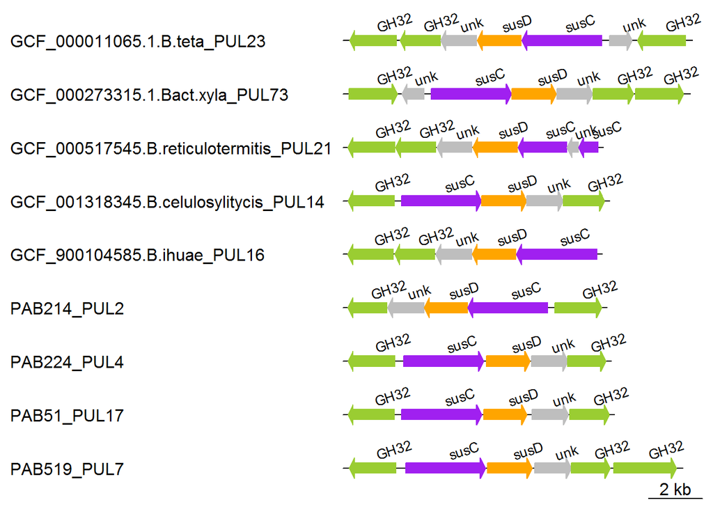

```r
plot_gene_map(dna_segs=dna_segs,annotations = annots)
```

**At the end we can save this plot into a pdf using the *pdf* function**

```r
pdf("MyFirstGenoPlotR.pdf")
plot_gene_map(dna_segs=dna_segs,annotations = annots)
dev.off()
```